# Week 3_Assignment

2021 5 22

## Analysis Idea

I want to know about racism in shooting incident.

So, Hypothesis is  
H1 : racism is decreased as time passes

In this analysis, racism shooting incident is defined when perpetrator’s race and victim’s race aren’t same.

*Caution : This is not following any kind of theory.*

## Import Data

Read library what we need for analysis

```r
library(tidyverse)
library(lubridate)
```

We need to get dataset from website.  
I got NYPD Shooting Incident Data from Data.gov.

```r
url <- "https://data.cityofnewyork.us/api/views/833y-fsy8/rows.csv?accessType=DOWNLOAD"
NYPD_shoot_inci <- read_csv(url)
```

## Data Cleaning / Managing

Keep the data that what we will use as a variable

I only use YEAR and RACE variables.

below data have year and race information.

- OCCUR_DATE
- PERP_RACE
- VIC_RACE

So, Make new dataframe that just keep 3 information.

```r
shoot_race_year <- NYPD_shoot_inci %>%
  mutate(date = mdy(OCCUR_DATE)) %>%
  select(c(date,PERP_RACE,VIC_RACE))
```

And, clear NULL data.

```r
shoot_race_year <- na.omit(shoot_race_year)
```

We need to get year when shoot incident occurs and unequal between perpetrator and victim.

So, using shoot_race_year dataframe, we make 2 new variables

1. YEAR : Year that shooting incident was occurred.
2. RACISM :
   - 0(Race of perpetrator and victim is equal)
   - 1(Race of perpetrator and victim is unequal)

```r
shoot_race_year$YEAR <- year(shoot_race_year$date)
```

```r
shoot_race_year$RACISM <- ifelse(shoot_race_year$PERP_RACE == shoot_race_year$VIC_RACE, 0, 1)
```

And then, Calcualte RACISM shooting incident and total incident number per year.

```r
shoot_by_year <- shoot_race_year %>%
  group_by(YEAR) %>%
  summarize(RACISM_inci = sum(RACISM), total_inci = n()) %>%
  select(YEAR, RACISM_inci, total_inci)

shoot_by_year$non_RACISM_inci <- shoot_by_year$total_inci - shoot_by_year$RACISM_inci
shoot_by_year$RACISM_inci_ratio <- shoot_by_year$RACISM_inci / shoot_by_year$total_inci
```

## Analysis

Let’s look at the descriptive statistics of Dataset

```r
summary(shoot_by_year)
```

```
##       YEAR       RACISM_inci      total_inci   non_RACISM_inci
##  Min.   :2006   Min.   :168.0   Min.   : 515   Min.   : 335.0
##  1st Qu.:2010   1st Qu.:231.5   1st Qu.: 665   1st Qu.: 426.0
##  Median :2013   Median :274.0   Median : 788   Median : 504.0
##  Mean   :2013   Mean   :399.1   Mean   :1010   Mean   : 610.5
##  3rd Qu.:2016   3rd Qu.:571.0   3rd Qu.:1408   3rd Qu.: 760.5
##  Max.   :2020   Max.   :839.0   Max.   :1924   Max.   :1116.0
##  RACISM_inci_ratio
##  Min.   :0.3124
##  1st Qu.:0.3415
##  Median :0.3599
##  Mean   :0.3774
##  3rd Qu.:0.4105
##  Max.   :0.5125
```

When we look at the number of Racism incident number by year, it looks like decreasing.

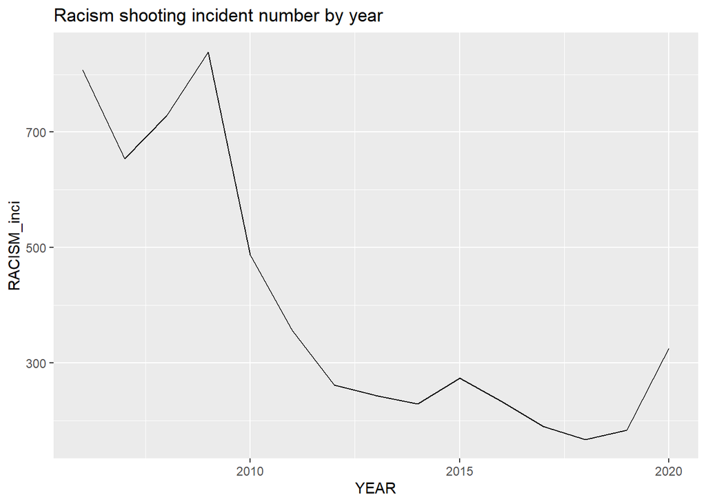

But, when we look at this data with total shoot incident number, Total number of shooting incident also decrease.

Below Bar chart shows that total shoot incident and Ratio of RACISM incident per total incident are gradually decreasing.

- Black bar is total number of shoot incident
- Red bar is RACISM number of shoot incident
- White text is ratio of RACISM incident per total incident

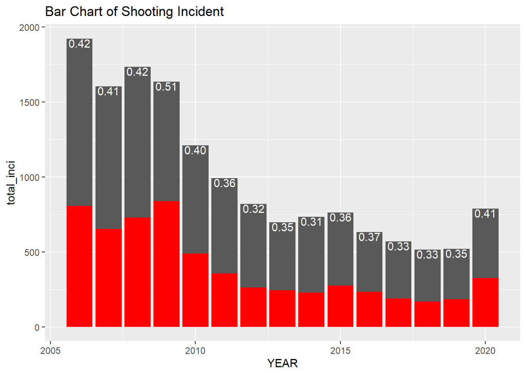

So, I do simple linear regression for finding the correlation of racism with time.

Relationship with two variables shows that we doesn’t have enough statistical evidence about hypothesis.

```r
model <- lm(RACISM_inci_ratio ~ YEAR, data = shoot_by_year)
summary(model)
```

```
##
## Call:
## lm(formula = RACISM_inci_ratio ~ YEAR, data = shoot_by_year)
##
## Residuals:
##       Min        1Q    Median        3Q       Max
## -0.063825 -0.024806 -0.005598  0.011487  0.111495
##
## Coefficients:
##              Estimate Std. Error t value Pr(>|t|)
## (Intercept) 12.247947   5.692888   2.151   0.0508 .
## YEAR        -0.005897   0.002828  -2.085   0.0573 .
## ---
## Signif. codes:  0 '***' 0.001 '**' 0.01 '*' 0.05 '.' 0.1 ' ' 1
##
## Residual standard error: 0.04732 on 13 degrees of freedom
## Multiple R-squared:  0.2506, Adjusted R-squared:  0.193
## F-statistic: 4.348 on 1 and 13 DF,  p-value: 0.05734
```

It is also seen in the linear regression’s line graph.

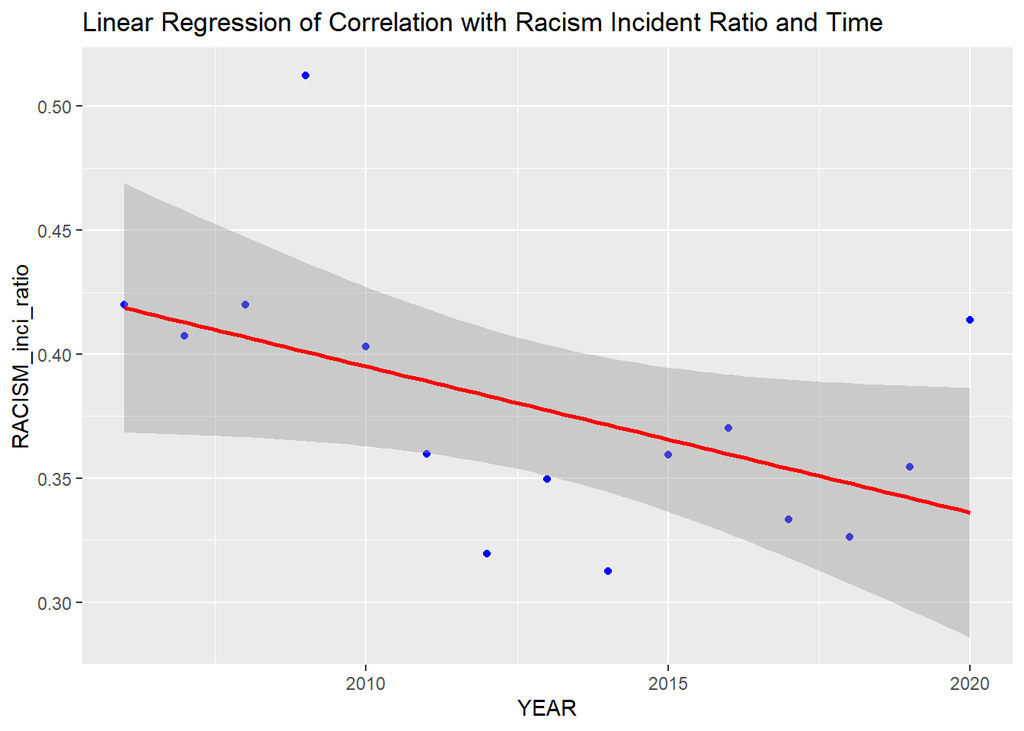

## Limitation and Bias

1. Data : Data have limitation that only shows about shoot incident and location limited only NYC.
2. Variable : Variable’s operational definition aren’t strict. It doesn’t represent term.
3. Analysis method : Analysis only used two simple variables. It doesn’t explain about whole situation.